# random_forest_winter_break_project

Darryl Nagal

2025-12-23

## Installing packages for random forest regression

```r
library(tidyverse)
library(caret)
```

## Importing the Boston Housing dataset and setting it as a dataframe called “bh”

```r
bh <- read.csv("~/Desktop/BostonHousing.csv")
```

## Taking a quick glance at the dataset and the variables it contains

```r
str(bh)
```

```
## 'data.frame':    506 obs. of  14 variables:
##  $ crim   : num  0.00632 0.02731 0.02729 0.03237 0.06905 ...
##  $ zn     : num  18 0 0 0 0 0 12.5 12.5 12.5 12.5 ...
##  $ indus  : num  2.31 7.07 7.07 2.18 2.18 2.18 7.87 7.87 7.87 7.87 ...
##  $ chas   : int  0 0 0 0 0 0 0 0 0 0 ...
##  $ nox    : num  0.538 0.469 0.469 0.458 0.458 0.458 0.524 0.524 0.524 0.524 ...
##  $ rm     : num  6.58 6.42 7.18 7 7.15 ...
##  $ age    : num  65.2 78.9 61.1 45.8 54.2 58.7 66.6 96.1 100 85.9 ...
##  $ dis    : num  4.09 4.97 4.97 6.06 6.06 ...
##  $ rad    : int  1 2 2 3 3 3 5 5 5 5 ...
##  $ tax    : int  296 242 242 222 222 222 311 311 311 311 ...
##  $ ptratio: num  15.3 17.8 17.8 18.7 18.7 18.7 15.2 15.2 15.2 15.2 ...
##  $ b      : num  397 397 393 395 397 ...
##  $ lstat  : num  4.98 9.14 4.03 2.94 5.33 ...
##  $ medv   : num  24 21.6 34.7 33.4 36.2 28.7 22.9 27.1 16.5 18.9 ...
```

```r
summary(bh)
```

```
##       crim                zn             indus            chas
##  Min.   : 0.00632   Min.   :  0.00   Min.   : 0.46   Min.   :0.00000
##  1st Qu.: 0.08205   1st Qu.:  0.00   1st Qu.: 5.19   1st Qu.:0.00000
##  Median : 0.25651   Median :  0.00   Median : 9.69   Median :0.00000
##  Mean   : 3.61352   Mean   : 11.36   Mean   :11.14   Mean   :0.06917
##  3rd Qu.: 3.67708   3rd Qu.: 12.50   3rd Qu.:18.10   3rd Qu.:0.00000
##  Max.   :88.97620   Max.   :100.00   Max.   :27.74   Max.   :1.00000
##
##       nox               rm             age              dis
##  Min.   :0.3850   Min.   :3.561   Min.   :  2.90   Min.   : 1.130
##  1st Qu.:0.4490   1st Qu.:5.884   1st Qu.: 45.02   1st Qu.: 2.100
##  Median :0.5380   Median :6.208   Median : 77.50   Median : 3.207
##  Mean   :0.5547   Mean   :6.284   Mean   : 68.57   Mean   : 3.795
##  3rd Qu.:0.6240   3rd Qu.:6.625   3rd Qu.: 94.08   3rd Qu.: 5.188
##  Max.   :0.8710   Max.   :8.780   Max.   :100.00   Max.   :12.127
##                   NA's   :5
##       rad              tax           ptratio            b
##  Min.   : 1.000   Min.   :187.0   Min.   :12.60   Min.   :  0.32
##  1st Qu.: 4.000   1st Qu.:279.0   1st Qu.:17.40   1st Qu.:375.38
##  Median : 5.000   Median :330.0   Median :19.05   Median :391.44
##  Mean   : 9.549   Mean   :408.2   Mean   :18.46   Mean   :356.67
##  3rd Qu.:24.000   3rd Qu.:666.0   3rd Qu.:20.20   3rd Qu.:396.23
##  Max.   :24.000   Max.   :711.0   Max.   :22.00   Max.   :396.90
##
##      lstat            medv
##  Min.   : 1.73   Min.   : 5.00
##  1st Qu.: 6.95   1st Qu.:17.02
##  Median :11.36   Median :21.20
##  Mean   :12.65   Mean   :22.53
##  3rd Qu.:16.95   3rd Qu.:25.00
##  Max.   :37.97   Max.   :50.00
##
```

## Removing all missing observations from the BH dataframe

The new dataframe will be called “bh_clean”

```r
bh_clean <- na.omit(bh)
sum(is.na(bh_clean))
```

```
## [1] 0
```

## Checking for duplicate values in the bh_clean dataframe

```r
sum(duplicated(bh_clean))
```

```
## [1] 0
```

## Ensuring reproducible results using set.seed(123) and splitting the bh_clean dataframe into train and test splits for machine learning

```r
set.seed(123)
n <- nrow(bh_clean) #counts the number of rows in bh_clean and sets this number as "n" which will be used later
train_idx <- sample(seq_len(n), size = 0.7 * n) #a 70-30 split is used for this project
```

## Establishing the 70-30 split and calling them “train” and “test”

```r
train <- bh_clean[train_idx, ]
test <- bh_clean[-train_idx, ]
```

## Using the randomForest library to perform a random forest regression

```r
library(randomForest)
```

## Cleaning the train and test splits to ensure that they do not contain any missing values

```r
train_clean <- na.omit(train)
test_clean  <- na.omit(test)
```

## Random Forest Regression Model using the Train dataset. Also known as “training” the model.

The outcome variable is “medv” 500 trees will be used for this analysis Feature importance is included given the last line of code

```r
rf_model <- randomForest(
  medv ~ .,
  data = train_clean,
  ntree = 500,
  mtry = floor(sqrt(ncol(train_clean)-1)),
  importance = TRUE
)

rf_model
```

```
##
## Call:
##  randomForest(formula = medv ~ ., data = train_clean, ntree = 500,      mtry = floor(sqrt(ncol(train_clean) - 1)), importance = TRUE)
##                Type of random forest: regression
##                      Number of trees: 500
## No. of variables tried at each split: 3
##
##           Mean of squared residuals: 12.06577
##                     % Var explained: 86.43
```

## Creating predictions by applying the rf_model previously created toward the unobserved “test” dataset

```r
preds <- predict(rf_model, newdata = test_clean)

preds
```

```
##         1         3         6         8         9        13        16        18
## 28.345713 35.059507 27.902460 19.585432 19.056877 20.931350 20.577852 17.846360
##        19        20        29        30        39        40        46        48
## 18.272694 19.552315 19.109706 20.393183 21.691834 29.578040 20.775549 20.636984
##        49        51        52        58        60        61        62        65
## 19.996931 21.519277 22.676660 33.557143 21.621433 20.601747 20.467851 31.535543
##        68        71        73        74        78        82        91        99
## 20.981603 24.122134 23.457600 23.693051 21.260318 25.414450 23.615470 40.098560
##       101       103       104       105       107       112       118       124
## 23.472388 19.650119 19.886722 20.150878 18.254837 22.210774 20.195738 18.595544
##       127       128       130       132       135       137       143       144
## 17.821964 15.791638 15.674897 19.641744 15.423122 16.850828 17.458732 14.505790
##       147       149       152       154       155       161       162       167
## 15.237053 14.794075 18.134533 15.884374 17.610772 28.203217 43.794665 44.630147
##       172       174       176       180       186       187       188       193
## 21.633294 24.296360 27.617296 34.235767 26.675280 38.609287 28.939787 37.055533
##       195       197       207       211       212       213       218       221
## 29.617407 36.535473 23.118663 21.285553 20.988443 22.247090 23.744977 29.325023
##       224       226       233       236       238       239       244       246
## 26.470822 40.099388 43.516491 23.381016 34.401990 24.712972 25.296437 19.820234
##       247       253       263       264       265       269       276       280
## 22.215597 33.405597 43.290826 31.611571 35.444687 43.040411 32.006217 31.898273
##       289       292       300       301       302       305       306       312
## 23.390277 34.075500 32.462737 27.855460 25.016520 32.738583 26.840213 23.246230
##       316       317       318       323       329       330       332       338
## 20.347059 19.831040 20.145255 22.403130 21.478740 24.083590 20.639570 20.015720
##       343       345       351       362       365       366       368       375
## 24.065863 29.705213 24.787937 19.937725 32.171290 24.571303 18.989054 17.076584
##       382       385       391       392       393       403       404       409
## 11.131693  9.294079 13.646657 16.321085 10.529980 10.916436 10.150666 13.842790
##       410       412       413       418       421       423       428       429
## 15.231274 13.543914 12.600820  8.765128 13.804302 17.601638 13.183689 12.413002
##       433       437       438       442       451       456       457       459
## 19.372856 12.490299  9.927604 13.580026 15.103978 15.401610 15.367785 15.613516
##       464       466       467       470       474       476       477       479
## 20.619762 20.877335 16.542112 17.916776 25.809622 15.186916 17.387505 15.635627
##       483       488       489       490       495       504       505
## 29.199258 21.417624 14.642737 12.624614 20.410417 27.342234 23.992623
```

## RMSE tells us how far our predicted values, on average, are from the true/actual values

```r
rmse <- sqrt(mean((preds - test_clean$medv)^2))
rmse
```

```
## [1] 3.163596
```

## Explaining the percentage of the variance in the dependent variable that the model’s predictions can explain

```r
sst <- sum((test_clean$medv - mean(train_clean$medv))^2)  # total variance
sse <- sum((preds - test_clean$medv)^2)                    # unexplained variance
r2 <- 1 - sse/sst
r2
```

```
## [1] 0.8684707
```

## Checking feature importance to see which variables are most important for making accurate predictions (toward the model’s overall predictive power)

```r
importance(rf_model)
```

```
##           %IncMSE IncNodePurity
## crim    16.707057     2221.7890
## zn       4.691863      437.5089
## indus   10.630678     1820.5856
## chas     5.766510      413.6511
## nox     16.495244     2478.0730
## rm      28.082849     7454.2546
## age      8.588808      919.2145
## dis     17.281334     2201.5009
## rad      7.199770      452.5797
## tax      9.464417     1080.3338
## ptratio 15.280448     2210.8403
## b        8.719389      712.5320
## lstat   24.604531     7858.0048
```

## Plotting feature importance

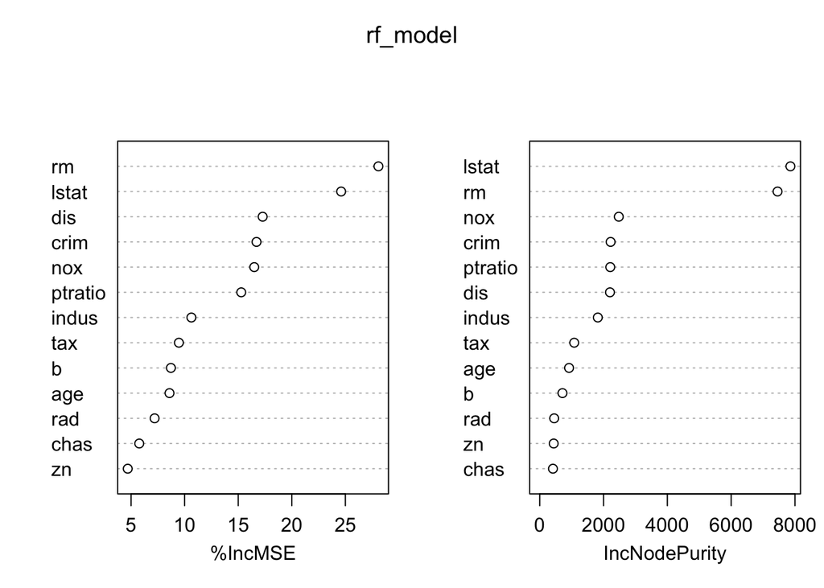

```r
varImpPlot(rf_model)
```

## Visualizing prediction values vs actual values

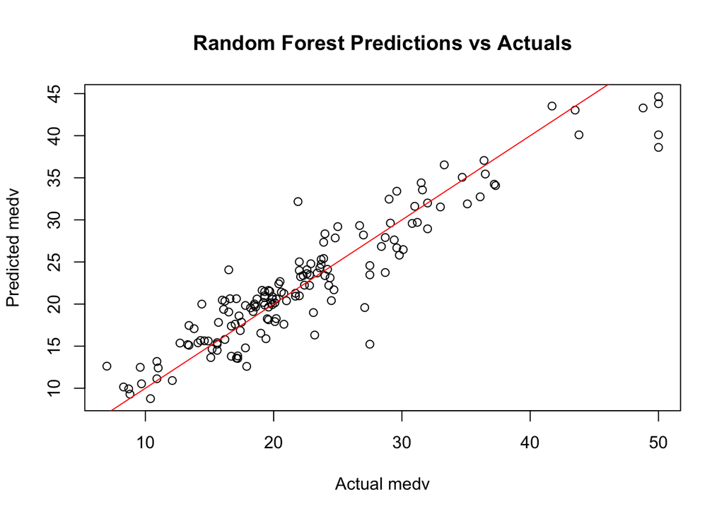

```r
plot(test_clean$medv, preds,
     xlab = "Actual medv",
     ylab = "Predicted medv",
     main = "Random Forest Predictions vs Actuals")
abline(a = 0, b = 1, col = "red")
```